# Homework week 10 day 3

```r
library(devtools)
```

```r
kc_house_data <- read_csv("data/kc_house_data.csv")
```

# Clean data

## Check contents of `waterfront`

```r
wf <- kc_house_data %>%
  distinct(waterfront)

wf
```

| waterfront |
| --- |
| 0 |
| 1 |

## Convert `waterfront` to true/false, drop na, drop unwanted or redundant fields

```r
kc_house_data_trim <- kc_house_data %>%
  drop_na() %>%
  mutate(waterfront = ifelse(waterfront == 1, TRUE, FALSE)) %>%
  select(-c(id, date, zipcode, sqft_living15, sqft_lot15))
```

## Check content of `yr_renovated` - do I want to make this logical?

I’m not going to use this field to make a logical variable - I’m not sure it’s complete for all records, or how “renovated” has been defined.

e.g.

- only 914 of 21,613 houses have ever been renovated according to the data
- of almost 5,000 properties built before 1950, only 12% had ever been renovated by 2014/15 These numbers don’t feel right.

I should probably model it anyway though to see what it does… but dropping it for the moment

**Number renovated/not renovated:**

```r
kc_house_data_trim %>%
  mutate(renovated = ifelse(yr_renovated == 0, FALSE, TRUE)) %>%
  group_by(renovated) %>%
  summarise(count = n())
```

| renovated | count |
| --- | --- |
| FALSE | 20699 |
| TRUE | 914 |

**Number built before 1950 and never renovated:**

```r
kc_house_data_trim %>%
  filter(yr_built < 1950) %>%
  mutate(renovated = ifelse(yr_renovated == 0, "Never renovated", "Renovated")) %>%
  group_by(renovated) %>%
  summarise(count = n())
```

| renovated | count |
| --- | --- |
| Never renovated | 4359 |
| Renovated | 578 |

**Number renovated/not renovated by build year:**

```r
kc_house_data_trim %>%
  mutate(renovated = ifelse(yr_renovated == 0, "Never renovated", "Renovated")) %>%
  group_by(yr_built, renovated) %>%
  summarise(count = n()) %>%
  pivot_wider(names_from = renovated, values_from = count) %>%
  arrange(yr_built)
```

| yr_built | Never renovated | Renovated |
| --- | --- | --- |
| 1900 | 68 | 19 |
| 1901 | 28 | 1 |
| 1902 | 25 | 2 |
| 1903 | 40 | 6 |
| 1904 | 39 | 6 |
| 1905 | 57 | 17 |
| 1906 | 84 | 8 |
| 1907 | 51 | 14 |
| 1908 | 72 | 14 |
| 1909 | 78 | 16 |

[output cut: 106 more lines]

**Drop yr_renovated**

```r
kc_house_data_trim <- kc_house_data_trim %>%
  select(-yr_renovated)
```

## condition and grade

These are categorical ordinal data types - the numbers have a hierarchy which means something regarding the quality of the house

# Aliased variables

This tells us that **sqft_living = sqft_above + sqft_basement**

Not totally sure which to remove:

- Do I just keep `sqft_living` because that’s the total?
- Or keep the other 2 to see if e.g. amount of basement space is important, whilst the total `sqft_living` can be derived?

I’ll drop `sqft_living` for the moment

**Check for alias**

```r
alias(price ~., data = kc_house_data_trim)
```

```
Model :
price ~ bedrooms + bathrooms + sqft_living + sqft_lot + floors +
    waterfront + view + condition + grade + sqft_above + sqft_basement +
    yr_built + lat + long

Complete :
              (Intercept) bedrooms bathrooms sqft_living sqft_lot floors
sqft_basement  0           0        0         1           0        0
              waterfrontTRUE view condition grade sqft_above yr_built lat long
sqft_basement  0              0    0         0    -1          0        0   0
```

**Visual check of `sqft` fields in data**

```r
kc_house_data_trim %>%
  mutate(check_sqft_living_minus_above = sqft_living - sqft_above) %>%
  select(sqft_living, sqft_above, sqft_basement, check_sqft_living_minus_above) %>%
  head(10)
```

| sqft_living | sqft_above | sqft_basement | check_sqft_living_minus_above |
| --- | --- | --- | --- |
| 1180 | 1180 | 0 | 0 |
| 2570 | 2170 | 400 | 400 |
| 770 | 770 | 0 | 0 |
| 1960 | 1050 | 910 | 910 |
| 1680 | 1680 | 0 | 0 |
| 5420 | 3890 | 1530 | 1530 |
| 1715 | 1715 | 0 | 0 |
| 1060 | 1060 | 0 | 0 |
| 1780 | 1050 | 730 | 730 |
| 1890 | 1890 | 0 | 0 |

**Drop sqft_living** See model building steps below - I’ve put this back in

```r
#kc_house_data_trim <- kc_house_data_trim %>%
#  select(-sqft_living)
```

# Look for first predictor

```r
#kc_house_data_trim %>%
#  ggpairs(aes(colour = waterfront, alpha = 0.5))
```

Not sure how to do that bit - just going to start with relationship between `price` and `sqft_above`

## model1 - above ground sq ft

```r
model1 <- lm(price ~ sqft_above, data = kc_house_data_trim)

model1
```

```
Call:
lm(formula = price ~ sqft_above, data = kc_house_data_trim)

Coefficients:
(Intercept)   sqft_above
    59953.2        268.5
```

So price = 59953.2 + 268.5*sqft_above

```r
summary(model1)
```

```
Call:
lm(formula = price ~ sqft_above, data = kc_house_data_trim)

Residuals:
    Min      1Q  Median      3Q     Max
-913132 -165624  -41468  109327 5339232

Coefficients:
            Estimate Std. Error t value Pr(>|t|)
(Intercept)  59953.2     4729.8   12.68   <2e-16 ***
sqft_above     268.5        2.4  111.87   <2e-16 ***
---
Signif. codes:  0 ‘***’ 0.001 ‘**’ 0.01 ‘*’ 0.05 ‘.’ 0.1 ‘ ’ 1

Residual standard error: 292200 on 21611 degrees of freedom
Multiple R-squared:  0.3667,    Adjusted R-squared:  0.3667
F-statistic: 1.251e+04 on 1 and 21611 DF,  p-value: < 2.2e-16
```

## model1 interpretation:

Above ground sqft is statistically significant, and explains 36% of varaiation in price

## model2 - above ground sq ft and basement sq ft

```r
model2 <- lm(price ~ sqft_above + sqft_basement, data = kc_house_data_trim)

model2
```

```
Call:
lm(formula = price ~ sqft_above + sqft_basement, data = kc_house_data_trim)

Coefficients:
  (Intercept)     sqft_above  sqft_basement
     -40860.0          276.7          295.5
```

```r
summary(model2)
```

```
Call:
lm(formula = price ~ sqft_above + sqft_basement, data = kc_house_data_trim)

Residuals:
     Min       1Q   Median       3Q      Max
-1503099  -147298   -23817   105296  4341387

Coefficients:
                Estimate Std. Error t value Pr(>|t|)
(Intercept)   -40859.961   4447.950  -9.186   <2e-16 ***
sqft_above       276.677      2.150 128.702   <2e-16 ***
sqft_basement    295.504      4.022  73.466   <2e-16 ***
---
Signif. codes:  0 ‘***’ 0.001 ‘**’ 0.01 ‘*’ 0.05 ‘.’ 0.1 ‘ ’ 1

Residual standard error: 261400 on 21610 degrees of freedom
Multiple R-squared:  0.4933,    Adjusted R-squared:  0.4932
F-statistic: 1.052e+04 on 2 and 21610 DF,  p-value: < 2.2e-16
```

## model2 interpretation:

This is still statistically significant, and now explains 49% of variance.

Maybe I should’ve just kept total sqft, at least to compare to this

I’m going to put it back in to try this

## model3 - sqft_living

```r
model3 <- lm(price ~ sqft_living, data = kc_house_data_trim)

model3
```

```
Call:
lm(formula = price ~ sqft_living, data = kc_house_data_trim)

Coefficients:
(Intercept)  sqft_living
   -43580.7        280.6
```

```r
summary(model3)
```

```
Call:
lm(formula = price ~ sqft_living, data = kc_house_data_trim)

Residuals:
     Min       1Q   Median       3Q      Max
-1476062  -147486   -24043   106182  4362067

Coefficients:
              Estimate Std. Error t value Pr(>|t|)
(Intercept) -43580.743   4402.690  -9.899   <2e-16 ***
sqft_living    280.624      1.936 144.920   <2e-16 ***
---
Signif. codes:  0 ‘***’ 0.001 ‘**’ 0.01 ‘*’ 0.05 ‘.’ 0.1 ‘ ’ 1

Residual standard error: 261500 on 21611 degrees of freedom
Multiple R-squared:  0.4929,    Adjusted R-squared:  0.4928
F-statistic: 2.1e+04 on 1 and 21611 DF,  p-value: < 2.2e-16
```

## model3 interpretation:

This has very similar results to using above ground & basement seperately, so for simplicity I’ll continue with model3 and drop the other two fields as redundant.

```r
kc_house_data_trim <- kc_house_data_trim %>%
  select(-c(sqft_above, sqft_basement))
```

## model4 - sqft & condition

```r
model4 <- lm(price ~ sqft_living + condition, data = kc_house_data_trim)

model4
```

```
Call:
lm(formula = price ~ sqft_living + condition, data = kc_house_data_trim)

Coefficients:
(Intercept)  sqft_living    condition
  -197180.0        282.5      43935.6
```

```r
summary(model4)
```

```
Call:
lm(formula = price ~ sqft_living + condition, data = kc_house_data_trim)

Residuals:
     Min       1Q   Median       3Q      Max
-1479034  -146743   -23437   105800  4317885

Coefficients:
              Estimate Std. Error t value Pr(>|t|)
(Intercept) -1.972e+05  1.047e+04  -18.83   <2e-16 ***
sqft_living  2.825e+02  1.928e+00  146.49   <2e-16 ***
condition    4.394e+04  2.721e+03   16.14   <2e-16 ***
---
Signif. codes:  0 ‘***’ 0.001 ‘**’ 0.01 ‘*’ 0.05 ‘.’ 0.1 ‘ ’ 1

Residual standard error: 259900 on 21610 degrees of freedom
Multiple R-squared:  0.4989,    Adjusted R-squared:  0.4989
F-statistic: 1.076e+04 on 2 and 21610 DF,  p-value: < 2.2e-16
```

## model4 interpretation:

This doesn’t seem to add anything to my model? Statistically significant, but still 49% of variation explained

## model5 - sqft & waterfront

```r
model5 <- lm(price ~ sqft_living + waterfront, data = kc_house_data_trim)

model5
```

```
Call:
lm(formula = price ~ sqft_living + waterfront, data = kc_house_data_trim)

Coefficients:
   (Intercept)     sqft_living  waterfrontTRUE
      -32957.9           272.5        829983.1
```

```r
summary(model5)
```

```
Call:
lm(formula = price ~ sqft_living + waterfront, data = kc_house_data_trim)

Residuals:
     Min       1Q   Median       3Q      Max
-1376782  -142867   -21360   107201  4449253

Coefficients:
                 Estimate Std. Error t value Pr(>|t|)
(Intercept)    -32957.851   4242.971  -7.768 8.35e-15 ***
sqft_living       272.507      1.873 145.499  < 2e-16 ***
waterfrontTRUE 829983.104  19882.279  41.745  < 2e-16 ***
---
Signif. codes:  0 ‘***’ 0.001 ‘**’ 0.01 ‘*’ 0.05 ‘.’ 0.1 ‘ ’ 1

Residual standard error: 251500 on 21610 degrees of freedom
Multiple R-squared:  0.5307,    Adjusted R-squared:  0.5307
F-statistic: 1.222e+04 on 2 and 21610 DF,  p-value: < 2.2e-16
```

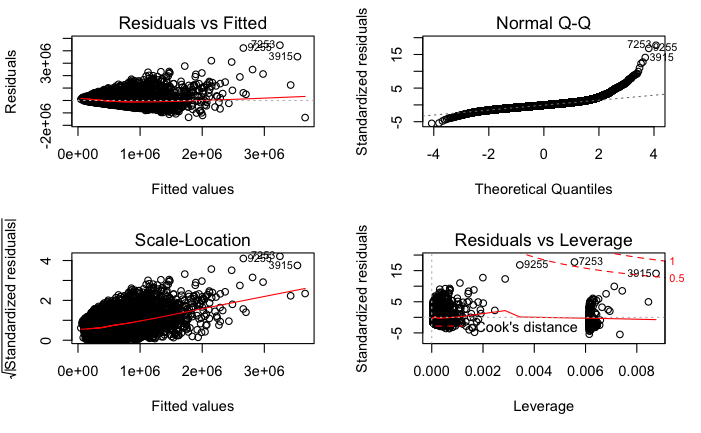

```r
par(mfrow = c(2, 2))

plot(model5)
View(kc_house_data_trim)
```

## model5 interpretation:

Statistically signficant, 53% of variation explained

### Next predictor:

Look at residuals: Not sure which to look at, or how to do it with numeric fields

```r
kc_house_data_remaining_resid <- kc_house_data_trim %>%
  add_residuals(model5) %>%
  select(-c("price", "sqft_living", "waterfront"))

#kc_house_data_remaining_resid %>%
#  ggpairs(aes(colour = bedrooms))
```

## ? try PCA

```r
kc_house_data_numeric <- kc_house_data_trim %>%
  select(-waterfront)
```

```r
kc_house_pca <- prcomp(kc_house_data_numeric, center = TRUE, scale. = TRUE)
```

```r
summary(kc_house_pca)
```

```
Importance of components:
                         PC1    PC2    PC3     PC4     PC5     PC6     PC7     PC8
Standard deviation     2.017 1.3340 1.1238 1.00661 0.96401 0.84578 0.82515 0.71283
Proportion of Variance 0.339 0.1483 0.1052 0.08444 0.07744 0.05961 0.05674 0.04234
Cumulative Proportion  0.339 0.4873 0.5925 0.67698 0.75442 0.81404 0.87078 0.91312
                           PC9    PC10    PC11    PC12
Standard deviation     0.63992 0.52927 0.45544 0.38146
Proportion of Variance 0.03412 0.02334 0.01729 0.01213
Cumulative Proportion  0.94724 0.97059 0.98787 1.00000
```

```r
install_github("vqv/ggbiplot")
```

```
Downloading GitHub repo vqv/ggbiplot@HEAD
```

[output not shown]

[output not shown]

[output not shown]

[output not shown]

```r
ggbiplot(kc_house_pca, obs.scale = 1, var.scale = 1)
```

```
Error in plot_label(p = p, data = plot.data, label = label, label.label = label.label,  :
  Unsupported class: prcomp
```